# R Notebook

```r
library(ISLR)
library(ggplot2)
library(dplyr)
library(reshape2)
set.seed(1)
```

## Problem 2

## Exercise 3

1. 3. is correct. Beta 3 adds 35k to the predicited salary if the person is a woman. However, beta 5 is an interaction term that lowers the predicted salary based on GPA only if the person is a woman. So, if a persons GPA is higher than 3.5, men make more than women on average.
2. Y = 50 + 20(4.0) + 0.07(110) + 35(1) + 0.01(4.0x110) - 10(4.0) = $137100
3. False. There is not enough information to determine this. It is possible that the interaction is still statistically significant even though it is small. Since no information is given on the p-value of the terms in the regression, the significance of the terms can’t be found.

## Exercise 4

1. We would expect the cubic regression to have a lower residual sum of squares because it will have a tighter fit on the training data.
2. We expect the linear regression to have a lower residual sum of squares on the test set because the true relationship is linear. This means the cubic regression would be overfit causing more error on the test set.
3. The cubic regression would have a lower residual sum of squares on the training set. Regardless of the true relationship, a more flexible model will always have lower error on the training set.
4. There is no way to tell which regression would have a lower RSS. The only information given on the true relationship of the model, only that it is not linear. Which model has a lower RSS on the test set depends on which one is closer to the true relationship. Since the true relationship is unknown, there is no way to tell which model has lower error. If the relationship is closer to linear than cubic, then the linear model will hace a lower RSS. If it is close to a cubic relationship, then the cubic model will have a lower RSS.

## Problem 3

## Exercise 9

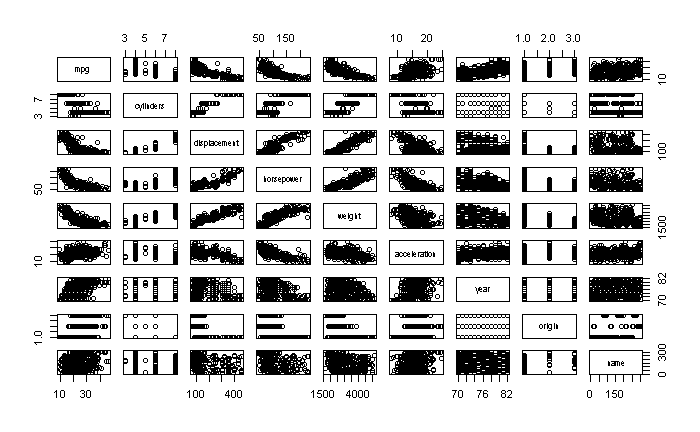

```r
pairs(Auto)
```

```r
cor(Auto[1:8])
```

```
                    mpg  cylinders displacement horsepower     weight acceleration       year     origin
mpg           1.0000000 -0.7776175   -0.8051269 -0.7784268 -0.8322442    0.4233285  0.5805410  0.5652088
cylinders    -0.7776175  1.0000000    0.9508233  0.8429834  0.8975273   -0.5046834 -0.3456474 -0.5689316
displacement -0.8051269  0.9508233    1.0000000  0.8972570  0.9329944   -0.5438005 -0.3698552 -0.6145351
horsepower   -0.7784268  0.8429834    0.8972570  1.0000000  0.8645377   -0.6891955 -0.4163615 -0.4551715
weight       -0.8322442  0.8975273    0.9329944  0.8645377  1.0000000   -0.4168392 -0.3091199 -0.5850054
acceleration  0.4233285 -0.5046834   -0.5438005 -0.6891955 -0.4168392    1.0000000  0.2903161  0.2127458
year          0.5805410 -0.3456474   -0.3698552 -0.4163615 -0.3091199    0.2903161  1.0000000  0.1815277
origin        0.5652088 -0.5689316   -0.6145351 -0.4551715 -0.5850054    0.2127458  0.1815277  1.0000000
```

```r
fit=lm(mpg~.-name,data = Auto)
summary(fit)
```

[output not shown]

1. There is a relationship between the predictors and the response because the p-value of the regression is extremely small
2. Displacement, weight, year, and origin all have a statistically significant relationship with the response.
3. The average mpg for cars goes up by 0.75 every year.

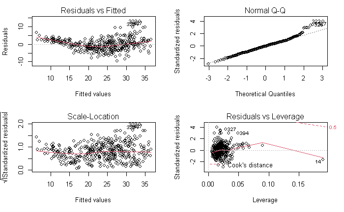

```r
par(mfrow=c(2,2))
plot(fit)
```

The fit of this model doesn’t appear to be very accurate because there is a clear curve in the residuals plot. The residual plot also shows a few outliers but they aren’t too unusually large.. The leverage plot shows that point 14 has a very high leverage, but it doesn’t have a very high magnitude residual.

```r
fit2 = lm(mpg~cylinders+displacement+horsepower+weight+acceleration+year+origin+weight*displacement+cylinders*displacement+weight*cylinders, data=Auto)
summary(fit2)
```

```
Call:
lm(formula = mpg ~ cylinders + displacement + horsepower + weight +
    acceleration + year + origin + weight * displacement + cylinders *
    displacement + weight * cylinders, data = Auto)

Residuals:
    Min      1Q  Median      3Q     Max
-9.9771 -1.8142 -0.0589  1.6557 12.1181

Coefficients:
                         Estimate Std. Error t value Pr(>|t|)
(Intercept)            -6.830e+00  6.090e+00  -1.122 0.262778
cylinders               5.961e-01  1.536e+00   0.388 0.698109
displacement           -8.595e-02  3.140e-02  -2.738 0.006480 **
horsepower             -3.552e-02  1.319e-02  -2.693 0.007404 **
weight                 -9.252e-03  2.355e-03  -3.929 0.000101 ***
acceleration            6.027e-02  8.905e-02   0.677 0.498978
year                    7.831e-01  4.574e-02  17.120  < 2e-16 ***
origin                  5.193e-01  2.706e-01   1.919 0.055685 .
displacement:weight     2.386e-05  6.162e-06   3.872 0.000127 ***
cylinders:displacement  1.923e-03  3.094e-03   0.622 0.534615
cylinders:weight       -2.515e-04  5.047e-04  -0.498 0.618481
---
Signif. codes:  0 ‘***’ 0.001 ‘**’ 0.01 ‘*’ 0.05 ‘.’ 0.1 ‘ ’ 1

Residual standard error: 2.97 on 381 degrees of freedom
Multiple R-squared:  0.8589,    Adjusted R-squared:  0.8552
F-statistic:   232 on 10 and 381 DF,  p-value: < 2.2e-16
```

I picked the three highest correlations from the correlation matrix as my interaction terms. As seen in the regression, the displacement and weight interaction term is the only one of the three that is statistically significant.

```r
fit3 = lm(mpg~cylinders+displacement+log(horsepower)+log(weight)+acceleration+year+origin, data=Auto)
summary(fit3)
```

```
Call:
lm(formula = mpg ~ cylinders + displacement + log(horsepower) +
    log(weight) + acceleration + year + origin, data = Auto)

Residuals:
    Min      1Q  Median      3Q     Max
-9.2167 -1.8307 -0.0454  1.6667 12.5849

Coefficients:
                  Estimate Std. Error t value Pr(>|t|)
(Intercept)     131.053301  11.006365  11.907  < 2e-16 ***
cylinders        -0.435022   0.292346  -1.488 0.137561
displacement      0.021086   0.006286   3.354 0.000875 ***
log(horsepower)  -6.166564   1.547548  -3.985 8.08e-05 ***
log(weight)     -17.370063   1.941388  -8.947  < 2e-16 ***
acceleration     -0.112081   0.101352  -1.106 0.269479
year              0.752507   0.046818  16.073  < 2e-16 ***
origin            1.131307   0.251405   4.500 9.02e-06 ***
---
Signif. codes:  0 ‘***’ 0.001 ‘**’ 0.01 ‘*’ 0.05 ‘.’ 0.1 ‘ ’ 1

Residual standard error: 3.032 on 384 degrees of freedom
Multiple R-squared:  0.8518,    Adjusted R-squared:  0.8491
F-statistic: 315.3 on 7 and 384 DF,  p-value: < 2.2e-16
```

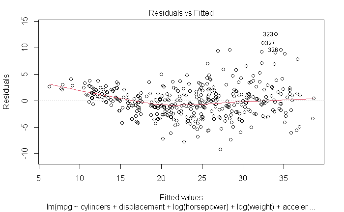

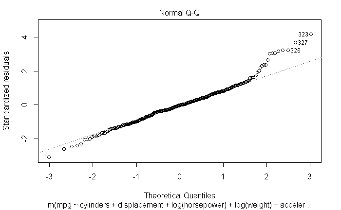

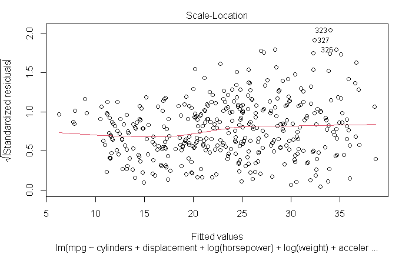

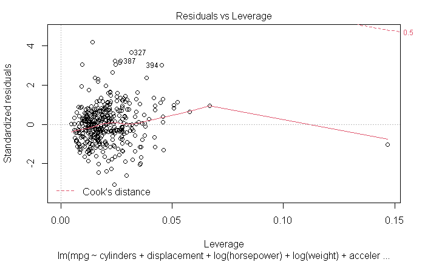

```r
plot(fit3)
```

## Exercise 10

```r
fit = lm(Sales~Price+Urban+US, data=Carseats)
summary(fit)
```

```
Call:
lm(formula = Sales ~ Price + Urban + US, data = Carseats)

Residuals:
    Min      1Q  Median      3Q     Max
-6.9206 -1.6220 -0.0564  1.5786  7.0581

Coefficients:
             Estimate Std. Error t value Pr(>|t|)
(Intercept) 13.043469   0.651012  20.036  < 2e-16 ***
Price       -0.054459   0.005242 -10.389  < 2e-16 ***
UrbanYes    -0.021916   0.271650  -0.081    0.936
USYes        1.200573   0.259042   4.635 4.86e-06 ***
---
Signif. codes:  0 ‘***’ 0.001 ‘**’ 0.01 ‘*’ 0.05 ‘.’ 0.1 ‘ ’ 1

Residual standard error: 2.472 on 396 degrees of freedom
Multiple R-squared:  0.2393,    Adjusted R-squared:  0.2335
F-statistic: 41.52 on 3 and 396 DF,  p-value: < 2.2e-16
```

```r
summary(Carseats)
```

```
     Sales          CompPrice       Income        Advertising       Population        Price        ShelveLoc
 Min.   : 0.000   Min.   : 77   Min.   : 21.00   Min.   : 0.000   Min.   : 10.0   Min.   : 24.0   Bad   : 96
 1st Qu.: 5.390   1st Qu.:115   1st Qu.: 42.75   1st Qu.: 0.000   1st Qu.:139.0   1st Qu.:100.0   Good  : 85
 Median : 7.490   Median :125   Median : 69.00   Median : 5.000   Median :272.0   Median :117.0   Medium:219
 Mean   : 7.496   Mean   :125   Mean   : 68.66   Mean   : 6.635   Mean   :264.8   Mean   :115.8
 3rd Qu.: 9.320   3rd Qu.:135   3rd Qu.: 91.00   3rd Qu.:12.000   3rd Qu.:398.5   3rd Qu.:131.0
 Max.   :16.270   Max.   :175   Max.   :120.00   Max.   :29.000   Max.   :509.0   Max.   :191.0
      Age          Education    Urban       US
 Min.   :25.00   Min.   :10.0   No :118   No :142
 1st Qu.:39.75   1st Qu.:12.0   Yes:282   Yes:258
 Median :54.50   Median :14.0
 Mean   :53.32   Mean   :13.9
 3rd Qu.:66.00   3rd Qu.:16.0
 Max.   :80.00   Max.   :18.0
```

2. Price: For each dollar increase in price, the average sales per location goes down by 54 Urban: The average sales per location is 22 less in urban stores vs rural stores. US: The average number of sales per store goes up by 1200 if the store is in the US
3. Sales = 13.043 + (-0.054)Price + (-.022)Urban + (1.201)US

   Urban and US are 1 if Yes, and 0 if No.
4. The null hypothesis can be rejected for Price and US because they ahve extremely low p-values.

```r
fit2 = lm(Sales~Price+US, data = Carseats)
summary(fit2)
```

```
Call:
lm(formula = Sales ~ Price + US, data = Carseats)

Residuals:
    Min      1Q  Median      3Q     Max
-6.9269 -1.6286 -0.0574  1.5766  7.0515

Coefficients:
            Estimate Std. Error t value Pr(>|t|)
(Intercept) 13.03079    0.63098  20.652  < 2e-16 ***
Price       -0.05448    0.00523 -10.416  < 2e-16 ***
USYes        1.19964    0.25846   4.641 4.71e-06 ***
---
Signif. codes:  0 ‘***’ 0.001 ‘**’ 0.01 ‘*’ 0.05 ‘.’ 0.1 ‘ ’ 1

Residual standard error: 2.469 on 397 degrees of freedom
Multiple R-squared:  0.2393,    Adjusted R-squared:  0.2354
F-statistic: 62.43 on 2 and 397 DF,  p-value: < 2.2e-16
```

```r
confint(fit2)
```

```
                  2.5 %      97.5 %
(Intercept) 11.79032020 14.27126531
Price       -0.06475984 -0.04419543
USYes        0.69151957  1.70776632
```

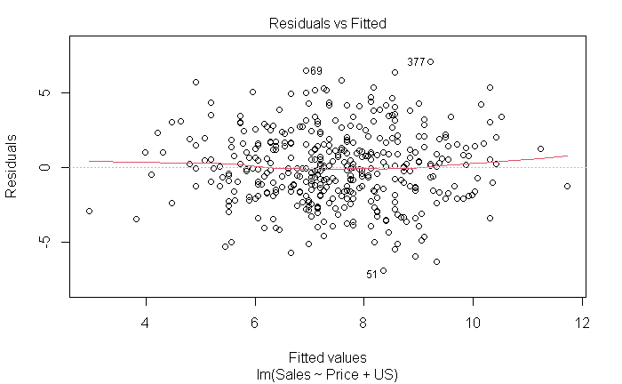

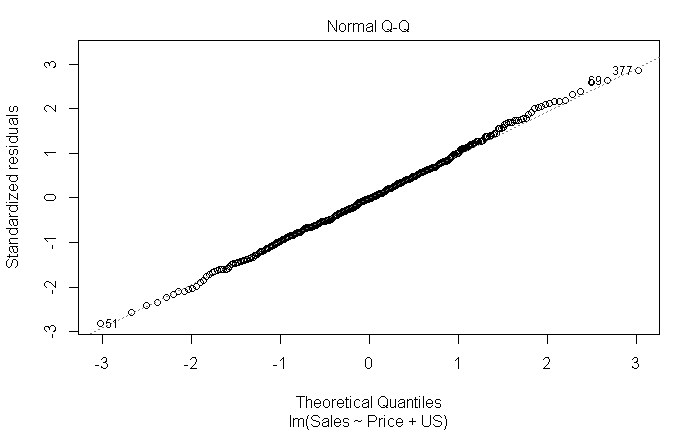

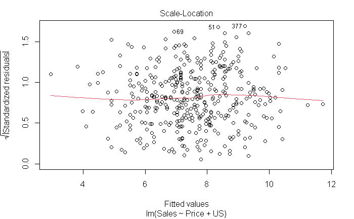

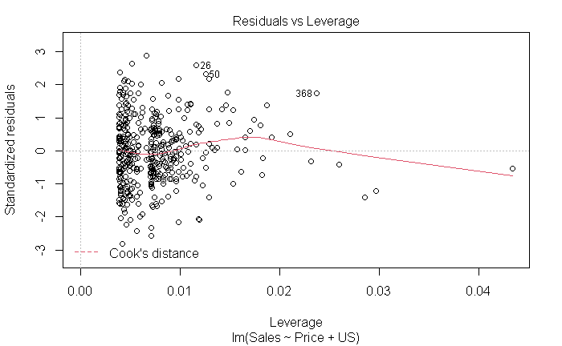

```r
plot(fit2)
```

The residual plot doesn’t show evidence of any extreme outliers. There a few points that have very high leverages as shown in the plot.

## Exercise 13

```r
x <- rnorm(100, 0, 1)
```

```r
eps <- rnorm(100, 0, 0.25)
```

```r
Y = -1 + 0.5*x + eps
```